# Ohio Medicaid Assessment Survey 2017

Thomas E. Love

2019-03-05

```r
library(here); library(haven); library(janitor)
library(naniar); library(broom); library(rms)
library(leaps); library(skimr); library(simputation)
library(readxl); library(knitr); library(kableExtra)
library(tidyverse)

skim_with(numeric = list(hist = NULL),
          integer = list(hist = NULL))
```

# 1 Data Management

## 1.1 Load Raw Data

```r
omas17_raw <- read_sas(here("data", "omas_2017_puf.sas7bdat"))
```

```r
dim(omas17_raw)
```

```
[1] 39711   370
```

## 1.2 Inclusions and Exclusions

```r
omas17_cleaning <- omas17_raw %>% clean_names() %>%
    # inclusion and exclusion criteria
    filter(a1 == 1,
           b4a == 1 | b4b == 1 | b4c == 1 | b4e == 1,
           d30binc > 47 & d30binc < 84,
           d30a_unit == 1,
           d30a_value > 59 & d30a_value < 450)
```

## 1.3 Initial Name Changes, Calculating BMI and Selection of Variables

Next, we’ll make some name changes, and calculate BMI from Weight and Height (but changing to NA any values that fall outside of the 16-80 range), then select the variables we want to study.

```r
omas17_cleaning <- omas17_cleaning %>%
    # name changes and minor transformations
    mutate(region = s9_region,
           county_type = s9_type_imp,
           sroh = d30_imp,
           age = age_a_imp,
           sex = s15,
           race_eth = race5_a_imp,
           usual_care = usual_a,
           ins_employer = b4a,
           ins_medicare = b4b,
           ins_medicaid = b4c,
           ins_private = b4e,
           mental31 = d30i,
           education = educ_imp,
           poverty = fpl_cat_18,
           ht_in = d30binc,
           wt_lb = d30a_value,
           smoke_100 = d45,
           alcohol30 = d46,
           er_visits = e62,
           job_today = g71)
```

## 1.4 Changing “Don’t Know” and “Refused” to `NA` with `naniar`

Now, we tell R that the `97`, `98` and `99` values are all in fact missing values, except for those we seein the `wt_lb` variable. We’ll use the `replace_with_na_at` function from the `naniar` package.

```r
omas17_cleaning <- omas17_cleaning %>%
    replace_with_na_at(.vars = c("alcohol30", "avoid_care",
                                 "ins_employer", "ins_medicare",
                                 "ins_medicaid", "ins_private",
                                 "er_visits", "food_12mo",
                                 "job_today", "marital",
                                 "mental31", "sex",
                                 "smoke_100", "usual_care"),
                       condition = ~.x %in% c(97, 98, 99))
```

## 1.5 Converting Categorical Variables

Now, we convert the categorical variables to meaningful factors or to 1/0 numeric variables.

```r
omas17_cleaning <- omas17_cleaning %>%
    mutate(region = fct_recode(factor(region),
                               "North_Central" = "1",
                               "North_East" = "2",
                               "North_East_Central" = "3",
                               "North_West" = "4",
                               "South_Central" = "5",
                               "South_East" = "6",
                               "South_West" = "7"),
           county_type = fct_recode(factor(county_type),
                             "Rural_Appalachian" = "1",
                             "Metro" = "2",
                             "Rural_Non-Appalachian" = "3",
                             "Suburban" = "4"),
           age = fct_recode(factor(age),
                            "19-24" = "1",
                            "25-34" = "2",
                            "35-44" = "3",
                            "45-54" = "4",
                            "55-64" = "5",
                            "65+" = "6"),
           sex = fct_recode(factor(sex),
                            "M" = "1",
                            "F" = "2"),
           race_eth = fct_recode(factor(race_eth),
                                 "White" = "1",
                                 "Black/African-American" = "2",
                                 "Hispanic" = "3",
                                 "Asian" = "4",
                                 "Other" = "5"),
           education = fct_recode(factor(education),
                             "1_Up To HS but no diploma" = "1",
                             "2_HS Graduate or equivalent" = "2",
                             "3_Some College" = "3",
                             "4_Associate Degree" = "4",
                             "5_Four Year College Graduate" = "5",
                             "6_Advanced Degree" = "6"),
           marital = fct_recode(factor(marital),
                                "Married" = "1",
                                "Divorced/Separated" = "2",
                                "Widowed" = "3",
                                "Never Married" = "4",
                                "Unmarried Couple" = "5"),
           poverty = fct_recode(factor(poverty),
                                "0.75 FPL or less" = "1",
                                "0.75 - 1.00 FPL" = "2",
                                "1.00 - 1.38 FPL" = "3",
                                "1.38 - 2.06 FPL" = "4",
                                "2.06 - 2.50 FPL" = "5",
                                "2.50 - 4.00 FPL" = "6",
                                "4.00 FPL or more" = "7"),
           food_12mo = fct_recode(factor(food_12mo),
                                  "1_Easier Now" = "1",
                                  "3_Harder Now" = "2",
                                  "2_Stayed Same" = "3",
                                  NULL = "4"),
           sroh = fct_recode(factor(sroh),
                             "1_Excellent" = "1",
                             "2_VeryGood" = "2",
                             "3_Good" = "3",
                             "4_Fair" = "4",
                             "5_Poor" = "5"),
           smoke_stat = fct_recode(factor(smoke_stat),
                                   "Never" = "1",
                                   "Former" = "2",
                                   "Current" = "3",
                                   NULL = "4"),
           # convert 1 = Yes, 2 = No to 1 = Yes, 0 = No
           job_today = 2 - job_today,
           smoke_100 = 2 - smoke_100,
           usual_care = 2 - usual_care,
           avoid_care = 2 - avoid_care,
           ins_employer = 2 - ins_employer,
           ins_medicare = 2 - ins_medicare,
           ins_medicaid = 2 - ins_medicaid,
           ins_private = 2 - ins_private)
```

## 1.6 Calculating BMI and Primary Insurance Type Selection of Variables

Next, we’ll make some name changes, and calculate BMI from Weight and Height (but changing to NA any values that fall outside of the 16-80 range), then we’ll assign everyone to a primary insurance type as follows:

- if they have Medicaid insurance, that will be their primary insurance type (`ins_type`)
- if not, and they have Medicare, that will be primary
- if neither, and they have Employer, that will be primary
- if none of those, and they have private, that will be primary

```r
omas17_cleaning <- omas17_cleaning %>%
    mutate(bmi = 703 * wt_lb/(ht_in^2)) %>%
    # restrict BMI to 16.0 through 80.0
    mutate(bmi = ifelse(bmi < 16 | bmi > 80, NA, bmi)) %>%
    mutate(ins_type = case_when(
        ins_medicaid == 1 ~ "Medicaid",
        ins_medicare == 1 ~ "Medicare",
        ins_employer == 1 ~ "Employer",
        ins_private == 1 ~ "Private",
        TRUE ~ NA_character_),
        ins_type = fct_relevel(factor(ins_type),
                               "Medicaid", "Medicare",
                               "Employer", "Private"))
```

## 1.7 Selection of Variables

Finally, we select the variables we want to study.

```r
omas17_cleaned <- omas17_cleaning %>%
    select(caseid, region, county_type, avoid_care,
           usual_care, ins_employer, ins_medicare,
           ins_medicaid, ins_private, ins_type,
           age, sex, race_eth, education, marital,
           poverty, job_today, food_12mo,
           sroh, mental31, ht_in, wt_lb, bmi,
           smoke_stat, smoke_100, alcohol30, er_visits)
```

## 1.8 Plot of missingness from `naniar`

```r
dim(omas17_cleaned)
```

```
[1] 32144    27
```

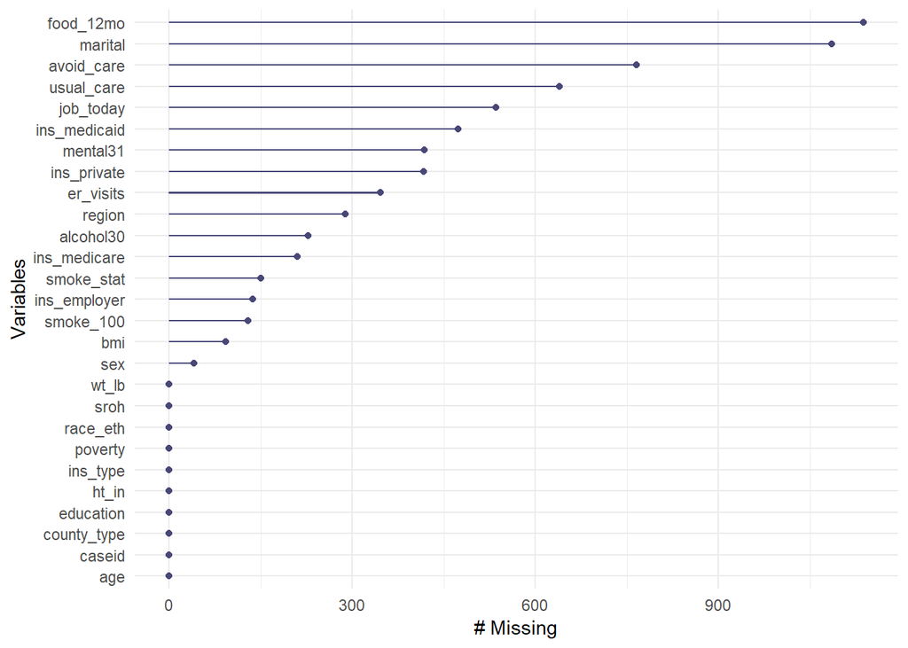

```r
gg_miss_var(omas17_cleaned)
```

```r
miss_var_summary(omas17_cleaned)
```

```
# A tibble: 27 x 3
   variable     n_miss pct_miss
   <chr>         <int>    <dbl>
 1 food_12mo      1137    3.54
 2 marital        1085    3.38
 3 avoid_care      766    2.38
 4 usual_care      640    1.99
 5 job_today       536    1.67
 6 ins_medicaid    474    1.47
 7 mental31        418    1.30
 8 ins_private     417    1.30
 9 er_visits       346    1.08
10 region          289    0.899
# ... with 17 more rows
```

## 1.9 Codebook

```r
omas_2017_codes <- read_xlsx(
    here("data", "omas_2017_codebook.xlsx"))

omas_2017_miss_summary <- miss_var_summary(omas17_cleaned)

omas_table <- left_join(omas_2017_codes, omas_2017_miss_summary)
omas_table %>%
    kable() %>%
    kable_styling(bootstrap_options = c("striped", "hover"))
```

| variable | type | description | source | n_miss | pct_miss |
| --- | --- | --- | --- | --- | --- |
| caseid | character | Identification Code - arbitrary | CASEID | 0 | 0.0000000 |
| region | 7-level factor | North_Central, North_East, North_East_Central, North_West, South_Central, South_East, South_West | S9_REGION | 289 | 0.8990791 |
| county_type | 4-level factor | Metro, Suburban, Rural Appalachian, Rural Non-Appalachian | Region | 0 | 0.0000000 |
| avoid_care | 1 (Yes), 0 (No) | Did you delayed or avoid getting the health care you needed? | AVOID_CARE | 766 | 2.3830264 |
| usual_care | 1 (Yes), 0 (No) | Do you have a usual source of care? | USUAL_A | 640 | 1.9910403 |
| ins_employer | 1 (Yes), 0 (No) | Insurance through an employer or union? | B4A | 137 | 0.4262071 |
| ins_medicare | 1 (Yes), 0 (No) | Insurance through Medicare? | B4B | 210 | 0.6533101 |
| ins_medicaid | 1 (Yes), 0 (No) | Insurance through Medicaid? | B4C | 474 | 1.4746142 |
| ins_private | 1 (Yes), 0 (No) | Insurance through a private plan? | B4E | 417 | 1.2972872 |
| ins_type | 4-level factor | Medicaid, Medicare, Employer, Private | Calculated | 0 | 0.0000000 |
| age | 6-level factor | Age category (in years): 19-24, 25-34, 35-44, 45-54, 55-64, 65+ | AGE_A_IMP | 0 | 0.0000000 |
| sex | 2-level factor | F = female, M = male | S15 | 41 | 0.1275510 |
| race_eth | 5-level factor | White, Black/African-American, Hispanic, Asian, Other | RACE5_A_IMP | 0 | 0.0000000 |
| education | 6-level factor | Up to HS but no diploma, HS Graduate or equivalent, Some College, Associate Degree, Four Year College Graduate, Advanced Degree | EDUC_IMP | 0 | 0.0000000 |
| marital | 5-level factor | Married, Divorced/Separated, Widowed, Never Married, Unmarried Couple | MARITAL | 1085 | 3.3754355 |
| poverty | 7-level factor | Relation to Federal Poverty Level of Household Income: 0.75 or less, 0.75-1, 1-1.38, 1.38-2.06, 2.06 - 2.5, 2.5 - 4, 4+ | FPL_CAT_18 | 0 | 0.0000000 |
| job_today | 1 (Yes), 0 (No) | Did you have a full-time or part-time job last week? | G71 | 536 | 1.6674963 |
| food_12mo | 3-level factor | Is it easier now, harder now or the same as one year ago to get food you need? | FOOD_12MO | 1137 | 3.5372076 |
| sroh | 5-level factor | Self-Reported Overall Health: Excellent, Very Good, Good, Fair, Poor | D30_IMP | 0 | 0.0000000 |
| mental31 | quantitative | # of days in the past month where your mental health prevented you from doing normal activities | D30I | 418 | 1.3003982 |
| ht_in | quantitative | height in inches | D30BINC | 0 | 0.0000000 |
| wt_lb | quantitative | weight in pounds | D30A_VALUE | 0 | 0.0000000 |
| bmi | quantitative | body-mass index (Calculated from Height and Weight, restricted to 16-80) | Calculated | 93 | 0.2893230 |
| smoke_stat | 3-level factor | Never Smoked, Former Smoker, Current Smoker | SMOKE_STAT | 150 | 0.4666501 |
| smoke_100 | 1 (Yes), 0 (No) | Have you smoked 100 cigarettes in your life? | D45 | 130 | 0.4044301 |
| alcohol30 | quantitative | # of days in the past 30 where you consumed alcohol | D46 | 228 | 0.7093081 |
| er_visits | quantitative | # of times in the past 12 months where you were a patient in a hospital emergency room | E62 | 346 | 1.0764062 |

## 1.10 Final Checks from `skim`

```r
skim(omas17_cleaned)
```

```
Skim summary statistics
 n obs: 32144
 n variables: 27

-- Variable type:character --------------------------------------------------------------------
 variable missing complete     n min max empty n_unique
   caseid       0    32144 32144   9   9     0    32144

-- Variable type:factor -----------------------------------------------------------------------
    variable missing complete     n n_unique
         age       0    32144 32144        6
 county_type       0    32144 32144        4
   education       0    32144 32144        6
   food_12mo    1137    31007 32144        3
    ins_type       0    32144 32144        4
     marital    1085    31059 32144        5
     poverty       0    32144 32144        7
    race_eth       0    32144 32144        5
      region     289    31855 32144        7
         sex      41    32103 32144        2
  smoke_stat     150    31994 32144        3
        sroh       0    32144 32144        5
                                              top_counts ordered
 65+: 10342, 55-: 7025, 45-: 5358, 35-: 3891               FALSE
 Met: 15666, Rur: 6220, Rur: 5223, Sub: 5035               FALSE
  2_H: 9810, 5_F: 6394, 3_S: 5041, 6_A: 4552               FALSE
  2_S: 22532, 3_H: 5681, 1_E: 2794, NA: 1137               FALSE
 Emp: 13560, Med: 9781, Med: 7167, Pri: 1636               FALSE
 Mar: 15274, Nev: 5364, Div: 5115, Wid: 3320               FALSE
                                           4.0: 10441, 2   FALSE
  Whi: 24889, Bla: 4188, Oth: 1912, His: 778               FALSE
  Nor: 8455, Sou: 7358, Sou: 6570, Sou: 3165               FALSE
                  F: 17607, M: 14496, NA: 41               FALSE
   Nev: 16891, For: 8538, Cur: 6565, NA: 150               FALSE
 2_V: 10059, 3_G: 9313, 1_E: 5659, 4_F: 5031               FALSE

-- Variable type:numeric ----------------------------------------------------------------------
     variable missing complete     n   mean    sd    p0    p25    p50
    alcohol30     228    31916 32144   4.1   7.32  0      0      1
   avoid_care     766    31378 32144   0.22  0.41  0      0      0
```

[output cut: 12 more lines]

```
    p75   p100
   4     30
   0      1
  32.35  78.64
   1     21
  70     83
   1      1
   0      1
   1      1
   0      1
   1      1
   0     31
   1      1
   1      1
 212    446
```

## 1.11 Saving the Results

```r
saveRDS(omas17_cleaned, here("data", "omas2017_clean.Rds"))
write_csv(omas17_cleaned, here("data", "omas2017_clean.csv"))
```

# 2 Model Building for a Quantitative Outcome

## 2.1 Working with a subsample: the Northeast Ohio Region

Let’s take a sample of the data, to describe the Northeast Ohio region.

```r
omas17ne <- omas17_cleaned %>%
    filter(region == "North_East")

nrow(omas17ne)
```

```
[1] 8455
```

The height/weight ratio (`hwr`) is usually expressed in cm / kg, rather than feet and inches. But we can convert.

$$ht_{cm} = 2.54 * ht_{in}, wt_{kg} = 0.453592 * wt_{lb}$$

and so

$$HWR = \frac{ht_{cm}}{wt_{kg}} \approx 5.6 \frac{ht_{in}}{wt_{lb}}$$

```r
omas17ne <- omas17ne %>%
    mutate(HWR = 5.6 * ht_in / wt_lb)
```

### 2.2.1 Summarizing the `HWR` Outcome

Here’s a quick numerical summary. We have no missing values, and for now, we’ll pretend that all of these values we do see are plausible.

```r
mosaic::favstats(~ HWR, data = omas17ne)
```

```
       min   Q1   median       Q3      max     mean        sd    n missing
 0.8195122 1.82 2.121212 2.453244 5.255385 2.152794 0.4810418 8455       0
```

### 2.2.2 Plotting the `HWR` Outcome

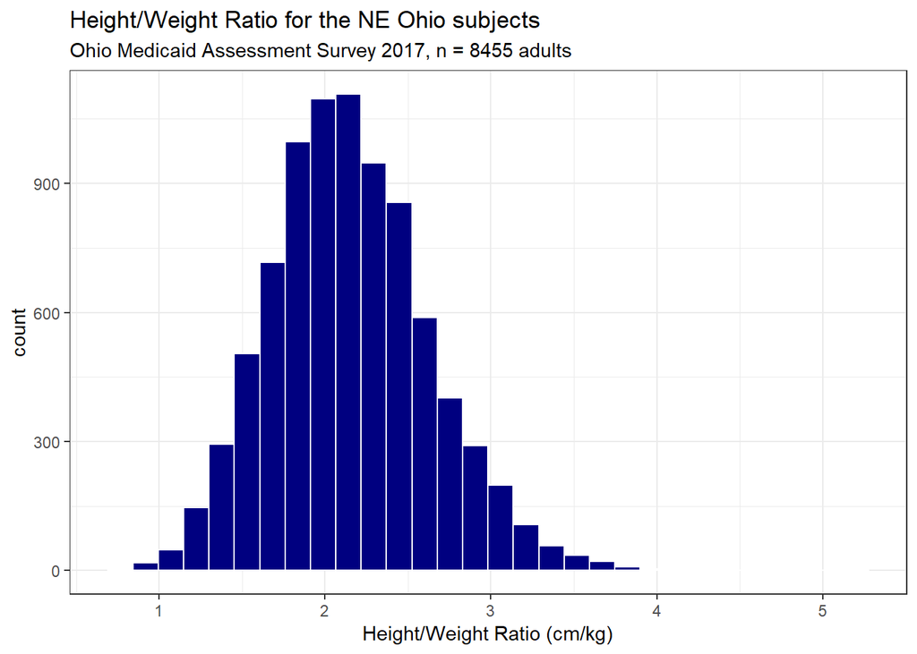

```r
ggplot(omas17ne, aes(x = HWR)) +
    geom_histogram(bins = 30, col = "white", fill = "navy") +
    theme_bw() +
    labs(x = "Height/Weight Ratio (cm/kg)",
         title = "Height/Weight Ratio for the NE Ohio subjects",
         subtitle = paste0("Ohio Medicaid Assessment Survey 2017, n = ", length(omas17ne$HWR), " adults"))
```

## 2.3 Predictors under consideration

- alcohol30 (quantitative - a count)
- mental31 (quantitative - a count)
- sex (2 levels)
- job_today (2 levels)
- usual_care (2 levels)
- smoke_100 (2 levels)
- smoke_stat (3 levels)
- ins_type (4 levels)
- sroh (5 levels)
- age (6 levels)
- education (6 levels)
- poverty (7 levels)

```r
str(omas17ne)
```

```
Classes 'tbl_df', 'tbl' and 'data.frame':   8455 obs. of  28 variables:
 $ caseid      : chr  "010002958" "010005008" "010006545" "010009985" ...
  ..- attr(*, "label")= chr "CASEID--Case ID"
 $ region      : Factor w/ 7 levels "North_Central",..: 2 2 2 2 2 2 2 2 2 2 ...
 $ county_type : Factor w/ 4 levels "Rural_Appalachian",..: 3 1 3 4 2 3 4 3 4 3 ...
 $ avoid_care  : num  1 0 0 0 0 0 0 0 0 0 ...
 $ usual_care  : num  1 0 1 1 1 1 1 1 1 0 ...
 $ ins_employer: num  1 0 0 0 0 0 0 1 0 0 ...
 $ ins_medicare: num  0 0 0 0 0 1 1 0 0 1 ...
 $ ins_medicaid: num  0 1 1 1 1 0 0 0 0 1 ...
 $ ins_private : num  1 0 0 0 0 0 1 0 1 0 ...
 $ ins_type    : Factor w/ 4 levels "Medicaid","Medicare",..: 3 1 1 1 1 2 2 3 4 1 ...
 $ age         : Factor w/ 6 levels "19-24","25-34",..: 1 5 1 5 1 6 6 4 2 4 ...
 $ sex         : Factor w/ 2 levels "M","F": 1 2 2 2 1 2 2 1 1 1 ...
 $ race_eth    : Factor w/ 5 levels "White","Black/African-American",..: 1 1 1 1 2 1 1 1 1 2 ...
```

[output cut: 21 more lines]

## 2.4 Running `regsubsets` with a multi-categorical predictor

### 2.4.1 Approach A

In Approach A, we treat `ins_type` as a factor, and use the formula interface, rather than `cbind`.

```r
hwr_out_A <- regsubsets(
    HWR ~ alcohol30 + mental31 + sex + ins_type,
    data = omas17ne, nvmax = NULL, nbest = 1)

hwr_summ_A <- summary(hwr_out_A)

hwr_summ_A$which # another option is outmat here
```

```
  (Intercept) alcohol30 mental31 sexF ins_typeMedicare ins_typeEmployer
1        TRUE     FALSE    FALSE TRUE            FALSE            FALSE
2        TRUE      TRUE    FALSE TRUE            FALSE            FALSE
3        TRUE      TRUE     TRUE TRUE            FALSE            FALSE
4        TRUE      TRUE     TRUE TRUE            FALSE            FALSE
5        TRUE      TRUE     TRUE TRUE             TRUE            FALSE
6        TRUE      TRUE     TRUE TRUE             TRUE             TRUE
  ins_typePrivate
1           FALSE
2           FALSE
3           FALSE
4            TRUE
5            TRUE
6            TRUE
```

```r
hwr_summ_A$adjr2
```

```
[1] 0.04804233 0.05644289 0.05787055 0.05876998 0.05948750 0.05976641
```

The result is problematic.

- How do we interpret models that have some but not all of the `ins_type` components?
- This is hiding the fact that missing data exist here, and that the machine is doing something about that to get these models. In fact, it’s dropping all of those observations.

### 2.4.2 Approach B

If we use the `cbind` approach, one “advantage” is that we get an error if we have missing data.

```r
hwr_preds_B <-
    with(omas17ne,
         cbind(alcohol30, mental31, sex, ins_type))

hwr_out_B <- regsubsets(x = hwr_preds_B,
                        y = omas17ne$HWR,
                        nvmax = NULL, nbest = 1)
```

If you try to run this you will get an error:

```
Error in leaps.setup(x, y, wt = weights, nbest = nbest, nvmax = nvmax, : NA/NaN/Inf in foreign function call (arg 4)
```

Aha! So we would need to either impute some of those values, or else do a complete case analysis.

### 2.4.3 Approach C

Let’s try the `cbind` approach after we restrict ourselves to complete cases.

```r
omas17ne_CC <- omas17ne %>%
    filter(complete.cases(caseid, HWR,
                          alcohol30, mental31,
                          sex, ins_type))

nrow(omas17ne_CC); nrow(omas17ne)
```

```
[1] 8273
```

```
[1] 8455
```

So we lose 182 rows due to missing data.

```r
hwr_preds_CC <-
    with(omas17ne_CC, cbind(alcohol30, mental31, sex, ins_type))

nrow(omas17ne_CC)
```

```
[1] 8273
```

```r
hwr_out_CC <- regsubsets(x = hwr_preds_CC,
                           y = omas17ne_CC$HWR,
                           nvmax = NULL, nbest = 1)

hwr_summ_CC <- summary(hwr_out_CC)

hwr_summ_CC$outmat # another option is which here
```

```
         alcohol30 mental31 sex ins_type
1  ( 1 ) " "       " "      "*" " "
2  ( 1 ) "*"       " "      "*" " "
3  ( 1 ) "*"       "*"      "*" " "
4  ( 1 ) "*"       "*"      "*" "*"
```

```r
hwr_summ_CC$adjr2
```

```
[1] 0.04804233 0.05644289 0.05787055 0.05854058
```

But, as it turns out, this is just the same as treating `ins_type` as if it were numeric! Which is kind of problematic, too!

```r
head(hwr_preds_CC)
```

```
     alcohol30 mental31 sex ins_type
[1,]        19        0   1        3
[2,]         2        0   2        1
[3,]         0        0   2        1
[4,]         0        0   2        1
[5,]        15        4   1        1
[6,]         0        0   2        2
```

### 2.4.4 Approach D

```r
omas17ne %>%
    mutate(ins_num = as.numeric(ins_type)) %>%
    tabyl(ins_type, ins_num)
```

```
 ins_type    1    2    3   4
 Medicaid 2029    0    0   0
 Medicare    0 2519    0   0
 Employer    0    0 3453   0
  Private    0    0    0 454
```

The formula approach hides two things:

- the missing data are removed before the regressions are run
- the multi-categorical factors are treated as if they were numeric

```r
hwr_out_D <- regsubsets(
    HWR ~ alcohol30 + mental31 + sex + as.numeric(ins_type),
    data = omas17ne, nvmax = NULL, nbest = 1)

hwr_summ_D <- summary(hwr_out_D)

hwr_summ_D$outmat
```

```
         alcohol30 mental31 sexF as.numeric(ins_type)
1  ( 1 ) " "       " "      "*"  " "
2  ( 1 ) "*"       " "      "*"  " "
3  ( 1 ) "*"       "*"      "*"  " "
4  ( 1 ) "*"       "*"      "*"  "*"
```

```r
hwr_summ_D$adjr2
```

```
[1] 0.04804233 0.05644289 0.05787055 0.05854058
```

### 2.4.5 Approach E

First impute, then use formula approach (still have the problem with multiple-category variables)

How much missingness is there in these variables?

```r
miss_var_summary(omas17ne %>%
                     select(alcohol30, mental31, sex,
                            ins_type, HWR))
```

```
# A tibble: 5 x 3
  variable  n_miss pct_miss
  <chr>      <int>    <dbl>
1 mental31     103    1.22
2 alcohol30     75    0.887
3 sex            9    0.106
4 ins_type       0    0
5 HWR            0    0
```

```r
set.seed(20190305)
omas17ne_imp1 <- omas17ne %>%
    impute_cart(sex ~ ins_type + HWR) %>%
    impute_rlm(alcohol30 ~ sex + ins_type + HWR) %>%
    impute_rlm(mental31 ~
                   alcohol30 + sex + ins_type + HWR)
```

```r
miss_var_summary(omas17ne_imp1 %>%
                     select(alcohol30, mental31, sex,
                            ins_type, HWR))
```

```
# A tibble: 5 x 3
  variable  n_miss pct_miss
  <chr>      <int>    <dbl>
1 alcohol30      0        0
2 mental31       0        0
3 sex            0        0
4 ins_type       0        0
5 HWR            0        0
```

```r
hwr_out_E <- regsubsets(
    HWR ~ alcohol30 + mental31 + sex + as.numeric(ins_type),
    data = omas17ne_imp1, nvmax = NULL, nbest = 1)

hwr_summ_E <- summary(hwr_out_E)

hwr_summ_E$outmat
```

```
         alcohol30 mental31 sexF as.numeric(ins_type)
1  ( 1 ) " "       " "      "*"  " "
2  ( 1 ) "*"       " "      "*"  " "
3  ( 1 ) "*"       "*"      "*"  " "
4  ( 1 ) "*"       "*"      "*"  "*"
```

```r
hwr_summ_E$adjr2
```

```
[1] 0.04737830 0.05492679 0.05667810 0.05722438
```

## 2.5 A More Complete Look at Potential Models

Our potential predictors are:

- alcohol30 (quantitative - a count)
- mental31 (quantitative - a count)
- sex (2 levels)
- job_today (2 levels)
- usual_care (2 levels)
- smoke_100 (2 levels)
- smoke_stat (3 levels)
- ins_type (4 levels)
- sroh (5 levels)
- age (6 levels)
- education (6 levels)
- poverty (7 levels)

```r
omas17ne %>%
    select(alcohol30, mental31, sex, job_today,
           usual_care, smoke_100, smoke_stat, ins_type,
           sroh, age, education, poverty, HWR) %>%
    miss_var_summary()
```

```
# A tibble: 13 x 3
   variable   n_miss pct_miss
   <chr>       <int>    <dbl>
 1 usual_care    187    2.21
 2 job_today     157    1.86
 3 mental31      103    1.22
 4 alcohol30      75    0.887
 5 smoke_stat     47    0.556
 6 smoke_100      43    0.509
 7 sex             9    0.106
 8 ins_type        0    0
 9 sroh            0    0
10 age             0    0
11 education       0    0
12 poverty         0    0
13 HWR             0    0
```

```r
set.seed(20190305)
omas17ne_imp2 <- omas17ne %>%
    impute_cart(sex + smoke_stat ~
                    ins_type + sroh + age + education +
                    poverty) %>%
    impute_pmm(smoke_100 ~
                    ins_type + sroh + age + education +
                    poverty + sex) %>%
    impute_pmm(alcohol30 + mental31 ~
                   ins_type + sroh + age + education +
                   poverty + sex + smoke_stat) %>%
    impute_pmm(job_today + usual_care ~
                   alcohol30 + sex + smoke_stat + age +
                    ins_type + mental31)
```

```r
omas17ne_imp2 %>%
    select(alcohol30, mental31, sex, job_today,
           usual_care, smoke_100, smoke_stat, ins_type,
           sroh, age, education, poverty, HWR) %>%
    miss_var_summary()
```

```
# A tibble: 13 x 3
   variable   n_miss pct_miss
   <chr>       <int>    <dbl>
 1 alcohol30       0        0
 2 mental31        0        0
 3 sex             0        0
 4 job_today       0        0
 5 usual_care      0        0
 6 smoke_100       0        0
 7 smoke_stat      0        0
 8 ins_type        0        0
 9 sroh            0        0
10 age             0        0
11 education       0        0
12 poverty         0        0
13 HWR             0        0
```

```r
omas17ne_imp2 %>%
    select(alcohol30, mental31, sex, job_today,
           usual_care, smoke_100, smoke_stat, ins_type,
           sroh, age, education, poverty, HWR) %>%
    skim()
```

```
Skim summary statistics
 n obs: 8455
 n variables: 13

-- Variable type:factor -----------------------------------------------------------------------
   variable missing complete    n n_unique
        age       0     8455 8455        6
  education       0     8455 8455        6
   ins_type       0     8455 8455        4
    poverty       0     8455 8455        7
        sex       0     8455 8455        2
 smoke_stat       0     8455 8455        3
       sroh       0     8455 8455        5
                                            top_counts ordered
  65+: 2757, 55-: 1843, 45-: 1430, 35-: 956              FALSE
 2_H: 2294, 5_F: 1821, 3_S: 1448, 6_A: 1322              FALSE
  Emp: 3453, Med: 2519, Med: 2029, Pri: 454              FALSE
                                          4.0: 2831, 2   FALSE
                    F: 4622, M: 3833, NA: 0              FALSE
     Nev: 4461, For: 2322, Cur: 1672, NA: 0              FALSE
 2_V: 2684, 3_G: 2361, 1_E: 1564, 4_F: 1322              FALSE

-- Variable type:numeric ----------------------------------------------------------------------
   variable missing complete    n mean   sd   p0  p25  p50  p75  p100
  alcohol30       0     8455 8455 4.51 7.66 0    0    1    5    30
        HWR       0     8455 8455 2.15 0.48 0.82 1.82 2.12 2.45  5.26
  job_today       0     8455 8455 0.53 0.5  0    0    1    1     1
   mental31       0     8455 8455 1.86 6.19 0    0    0    0    31
  smoke_100       0     8455 8455 0.47 0.5  0    0    0    1     1
 usual_care       0     8455 8455 0.94 0.24 0    1    1    1     1
```

```r
omas17ne_imp2 <- omas17ne_imp2 %>%
    mutate(age_num = as.numeric(age),
           educ_num = as.numeric(education),
           ins_num = as.numeric(ins_type),
           pov_num = as.numeric(poverty),
           smoke_num = as.numeric(smoke_stat),
           sroh_num = as.numeric(sroh))
```

```r
hwr_out_F <- regsubsets(
    HWR ~ alcohol30 + mental31 + sex + job_today +
        usual_care + smoke_100 + smoke_num + pov_num +
        ins_num + sroh_num + age_num + educ_num,
    data = omas17ne_imp2, nvmax = 12, nbest = 1)

hwr_summ_F <- summary(hwr_out_F)

hwr_summ_F$outmat
```

```
          alcohol30 mental31 sexF job_today usual_care smoke_100 smoke_num
1  ( 1 )  " "       " "      "*"  " "       " "        " "       " "
2  ( 1 )  " "       " "      "*"  " "       " "        " "       " "
3  ( 1 )  " "       " "      "*"  " "       " "        " "       "*"
4  ( 1 )  " "       " "      "*"  " "       " "        "*"       "*"
5  ( 1 )  " "       " "      "*"  "*"       " "        "*"       "*"
6  ( 1 )  "*"       " "      "*"  "*"       " "        "*"       "*"
7  ( 1 )  "*"       " "      "*"  "*"       " "        "*"       "*"
8  ( 1 )  "*"       " "      "*"  "*"       " "        "*"       "*"
9  ( 1 )  "*"       " "      "*"  "*"       "*"        "*"       "*"
10  ( 1 ) "*"       " "      "*"  "*"       "*"        "*"       "*"
11  ( 1 ) "*"       "*"      "*"  "*"       "*"        "*"       "*"
12  ( 1 ) "*"       "*"      "*"  "*"       "*"        "*"       "*"
          pov_num ins_num sroh_num age_num educ_num
1  ( 1 )  " "     " "     " "      " "     " "
2  ( 1 )  " "     " "     "*"      " "     " "
3  ( 1 )  " "     " "     "*"      " "     " "
4  ( 1 )  " "     " "     "*"      " "     " "
5  ( 1 )  " "     " "     "*"      " "     " "
6  ( 1 )  " "     " "     "*"      " "     " "
7  ( 1 )  " "     " "     "*"      "*"     " "
8  ( 1 )  "*"     " "     "*"      "*"     " "
9  ( 1 )  "*"     " "     "*"      "*"     " "
10  ( 1 ) "*"     "*"     "*"      "*"     " "
11  ( 1 ) "*"     "*"     "*"      "*"     " "
12  ( 1 ) "*"     "*"     "*"      "*"     "*"
```

### 2.5.1 Suggested Models from `regsubsets`

Data includes `nrow(omas17ne_imp2)` = 8455 observations, and we run models of size 2:13, when you include the intercept term here because we set `nvarmax = 12`…

```r
hwr_summ_F$aic.c <- 8455*log(hwr_summ_F$rss / 8455) + 2*(2:13) +
    (2 * (2:13) * ((2:13)+1) / (8455 - (2:13) - 1))
```

Now, we build a tibble containing the winners:

```r
hwr_F_win <- data_frame(
    k = 2:13,
    r2 = hwr_summ_F$rsq,
    adjr2 = hwr_summ_F$adjr2,
    cp = hwr_summ_F$cp,
    aic.c = hwr_summ_F$aic.c,
    bic = hwr_summ_F$bic)
hwr_F_win <- bind_cols(hwr_F_win, tbl_df(hwr_summ_F$which))
```

```r
hwr_F_win
```

```
# A tibble: 12 x 19
       k     r2  adjr2     cp   aic.c   bic `(Intercept)` alcohol30
   <int>  <dbl>  <dbl>  <dbl>   <dbl> <dbl> <lgl>         <lgl>
 1     2 0.0474 0.0473 592.   -12782. -392. TRUE          FALSE
 2     3 0.0870 0.0868 218.   -13139. -742. TRUE          FALSE
 3     4 0.0933 0.0930 160.   -13196. -792. TRUE          FALSE
 4     5 0.101  0.101   88.5  -13266. -855. TRUE          FALSE
 5     6 0.106  0.105   44.9  -13310. -892. TRUE          FALSE
 6     7 0.110  0.109   10.6  -13344. -919. TRUE          TRUE
 7     8 0.110  0.109    9.39 -13345. -913. TRUE          TRUE
 8     9 0.110  0.110    7.35 -13347. -908. TRUE          TRUE
 9    10 0.111  0.110    7.42 -13347. -901. TRUE          TRUE
10    11 0.111  0.110    9.16 -13345. -892. TRUE          TRUE
11    12 0.111  0.110   11.0  -13343. -883. TRUE          TRUE
12    13 0.111  0.109   13    -13342. -874. TRUE          TRUE
# ... with 11 more variables: mental31 <lgl>, sexF <lgl>, job_today <lgl>,
#   usual_care <lgl>, smoke_100 <lgl>, smoke_num <lgl>, pov_num <lgl>,
#   ins_num <lgl>, sroh_num <lgl>, age_num <lgl>, educ_num <lgl>
```

The models considered by `regsubsets` are:

| k | Model |
| --- | --- |
| 2 | `sex_F` |
| 3 | + `sroh_num` (sroh) |
| 4 | + `smoke_num` (smoke_stat) |
| 5 | + `smoke_100` |
| 6 | + `job_today` |
| 7 | + `alcohol30` |
| 8 | + `age_num` (age) |
| 9 | + `pov_num` (poverty) |
| 10 | + `usual_care` |
| 11 | + `ins_num` |
| 12 | + `mental31` |
| 13 | + `educ_num` |

#### 2.5.1.1 The Big Four Plots

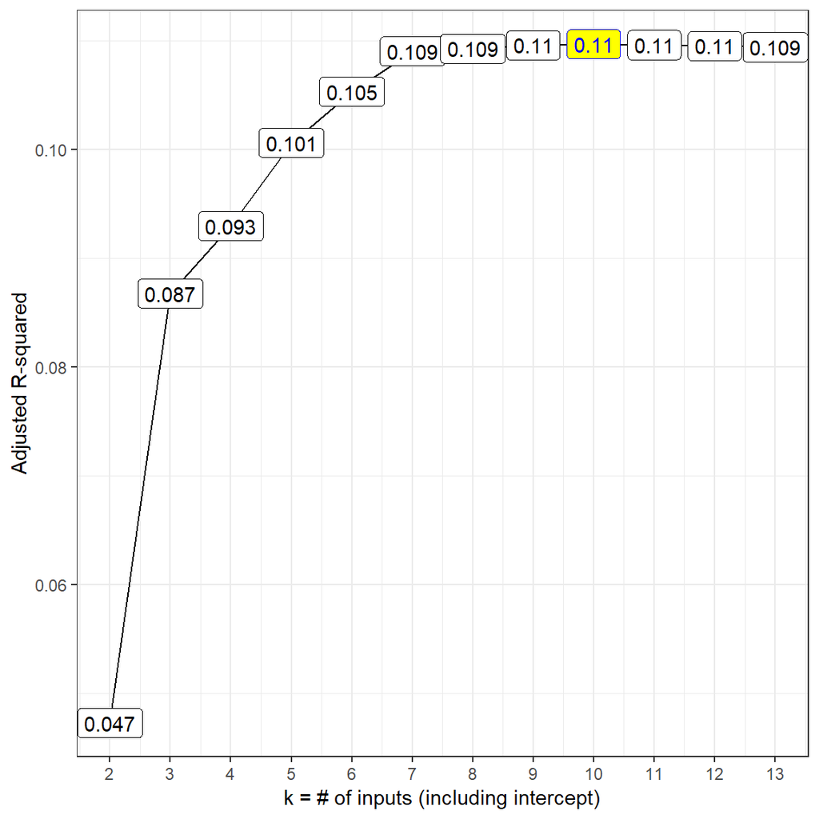

```r
hwrp1
```

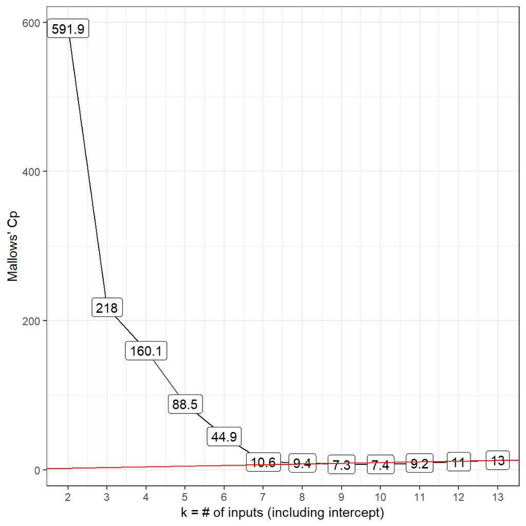

```r
hwrp2
```

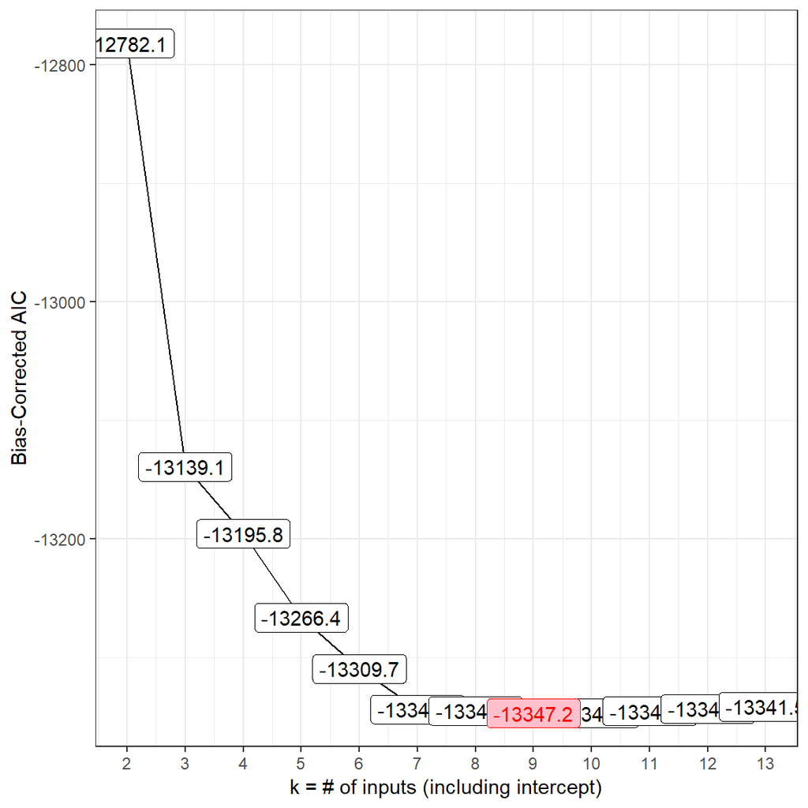

```r
hwrp3
```

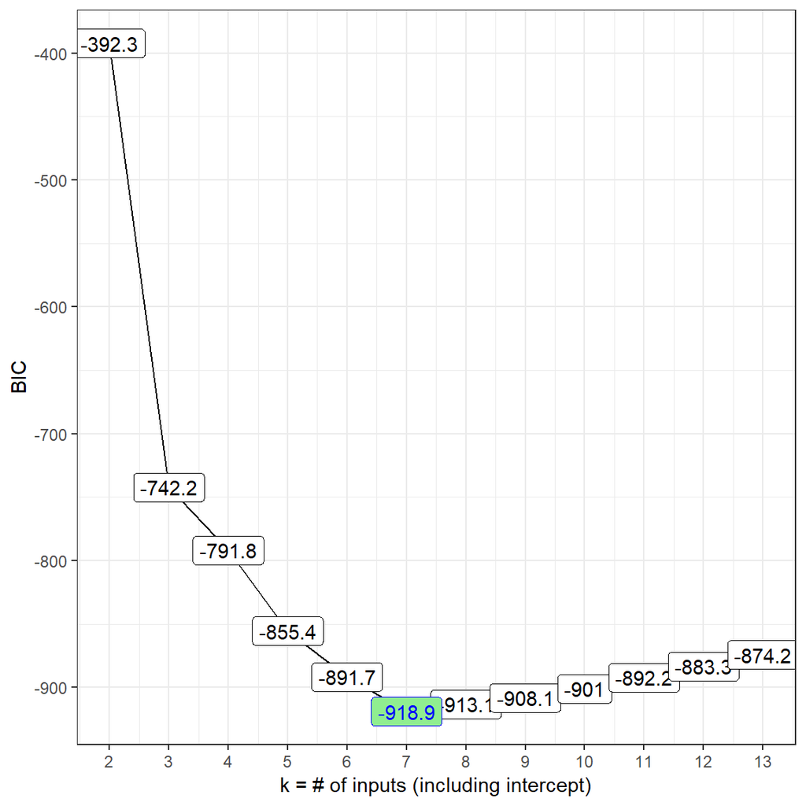

```r
hwrp4
```

### 2.5.2 A Stepwise Model with Numeric Predictors

```r
hwr_out_STEPNUM <- step(lm(
    HWR ~ alcohol30 + mental31 + sex + job_today +
        usual_care + smoke_100 + smoke_num + pov_num +
        ins_num + sroh_num + age_num + educ_num,
    data = omas17ne_imp2))
```

```
Start:  AIC=-13341.55
HWR ~ alcohol30 + mental31 + sex + job_today + usual_care + smoke_100 +
    smoke_num + pov_num + ins_num + sroh_num + age_num + educ_num

             Df Sum of Sq    RSS    AIC
- educ_num    1     0.003 1739.7 -13344
- mental31    1     0.030 1739.8 -13343
- ins_num     1     0.051 1739.8 -13343
- usual_care  1     0.393 1740.1 -13342
<none>                    1739.7 -13342
- pov_num     1     0.499 1740.2 -13341
- age_num     1     0.863 1740.6 -13339
- alcohol30   1     6.806 1746.5 -13310
- job_today   1    11.198 1750.9 -13289
- smoke_100   1    15.757 1755.5 -13267
- smoke_num   1    23.986 1763.7 -13228
- sroh_num    1    71.440 1811.2 -13003
- sex         1    95.911 1835.7 -12890

Step:  AIC=-13343.54
HWR ~ alcohol30 + mental31 + sex + job_today + usual_care + smoke_100 +
    smoke_num + pov_num + ins_num + sroh_num + age_num

             Df Sum of Sq    RSS    AIC
- mental31    1     0.030 1739.8 -13345
- ins_num     1     0.050 1739.8 -13345
- usual_care  1     0.398 1740.1 -13344
<none>                    1739.7 -13344
- pov_num     1     0.509 1740.2 -13343
- age_num     1     0.867 1740.6 -13341
- alcohol30   1     6.819 1746.6 -13312
- job_today   1    11.286 1751.0 -13291
- smoke_100   1    15.755 1755.5 -13269
- smoke_num   1    24.161 1763.9 -13229
- sroh_num    1    72.158 1811.9 -13002
- sex         1    95.920 1835.7 -12892

Step:  AIC=-13345.39
HWR ~ alcohol30 + sex + job_today + usual_care + smoke_100 +
    smoke_num + pov_num + ins_num + sroh_num + age_num
```

[output cut: 29 more lines]

```

Step:  AIC=-13347.2
HWR ~ alcohol30 + sex + job_today + smoke_100 + smoke_num + pov_num +
    sroh_num + age_num

            Df Sum of Sq    RSS    AIC
<none>                   1740.2 -13347
- pov_num    1     0.833 1741.0 -13345
- age_num    1     1.003 1741.2 -13344
- alcohol30  1     6.818 1747.0 -13316
- job_today  1    11.648 1751.9 -13293
- smoke_100  1    15.787 1756.0 -13273
- smoke_num  1    24.311 1764.5 -13232
- sroh_num   1    78.245 1818.5 -12977
- sex        1    95.490 1835.7 -12898
```

So the model that the stepwise approach (with numeric values forced for our multi-categorical variables) selects includes these 8 variables:

- smoke_100
- poverty
- job_today
- alcohol30
- age
- smoke_stat
- sroh
- sex

### 2.5.3 A Stepwise Model with Factors for Multi-Categorical Predictors

```r
hwr_out_STEPFAC <- step(lm(
    HWR ~ alcohol30 + mental31 + sex + job_today +
        usual_care + smoke_100 + smoke_stat + poverty +
        ins_type + sroh + age + education,
    data = omas17ne_imp2))
```

```
Start:  AIC=-13578.71
HWR ~ alcohol30 + mental31 + sex + job_today + usual_care + smoke_100 +
    smoke_stat + poverty + ins_type + sroh + age + education

             Df Sum of Sq    RSS    AIC
- smoke_100   1     0.092 1684.1 -13580
- usual_care  1     0.289 1684.3 -13579
- mental31    1     0.363 1684.4 -13579
<none>                    1684.0 -13579
- ins_type    3     1.655 1685.7 -13576
- poverty     6     2.974 1687.0 -13576
- job_today   1     2.818 1686.8 -13567
- education   5     6.771 1690.8 -13555
- alcohol30   1     6.121 1690.2 -13550
- age         5    19.845 1703.9 -13490
- smoke_stat  2    28.817 1712.8 -13439
- sroh        4    85.995 1770.0 -13166
- sex         1   100.318 1784.3 -13092

Step:  AIC=-13580.25
HWR ~ alcohol30 + mental31 + sex + job_today + usual_care + smoke_stat +
    poverty + ins_type + sroh + age + education

             Df Sum of Sq    RSS    AIC
- usual_care  1     0.285 1684.4 -13581
- mental31    1     0.362 1684.5 -13580
<none>                    1684.1 -13580
- ins_type    3     1.647 1685.8 -13578
- poverty     6     2.952 1687.1 -13577
- job_today   1     2.834 1687.0 -13568
- education   5     6.767 1690.9 -13556
- alcohol30   1     6.131 1690.3 -13552
- age         5    19.782 1703.9 -13492
- smoke_stat  2    30.825 1715.0 -13431
- sroh        4    85.919 1770.0 -13168
- sex         1   100.236 1784.4 -13093

Step:  AIC=-13580.81
HWR ~ alcohol30 + mental31 + sex + job_today + smoke_stat + poverty +
    ins_type + sroh + age + education
```

[output cut: 14 more lines]

```
Step:  AIC=-13581.04
HWR ~ alcohol30 + sex + job_today + smoke_stat + poverty + ins_type +
    sroh + age + education

             Df Sum of Sq    RSS    AIC
<none>                    1684.8 -13581
- ins_type    3     1.666 1686.4 -13579
- poverty     6     2.996 1687.8 -13578
- job_today   1     2.644 1687.4 -13570
- education   5     6.738 1691.5 -13557
- alcohol30   1     6.049 1690.8 -13553
- age         5    20.055 1704.8 -13491
- smoke_stat  2    30.689 1715.5 -13432
- sroh        4    89.220 1774.0 -13153
- sex         1    99.792 1784.5 -13096
```

So the model that the stepwise approach (with factors) selects includes these 9 variables:

- ins_type
- poverty
- job_today
- education
- alcohol30
- age
- smoke_stat
- sroh
- sex

### 2.5.4 Using cross-validation to make a decision between candidate models

How does `crossv_kfold` work? How does `crossv_mc` work?

## 2.6 Running a Spearman $\rho^2$ Plot

### 2.6.1 Should we impute missing values first?

To come.

### 2.6.2 What is the plot telling us? How about the testing?

```r
spear1 <- spearman2(HWR ~ sex + sroh + alcohol30 + mental31 +
                   age + education + smoke_stat + poverty,
               data = omas17ne, p = 1)
spear1
```

```
Spearman rho^2    Response variable:HWR

            rho2      F df1  df2      P Adjusted rho2    n
sex        0.047 413.85   1 8444 0.0000         0.047 8446
sroh       0.054 121.62   4 8450 0.0000         0.054 8455
alcohol30  0.003  28.14   1 8378 0.0000         0.003 8380
mental31   0.000   2.07   1 8350 0.1503         0.000 8352
age        0.015  25.61   5 8449 0.0000         0.014 8455
education  0.005   8.41   5 8449 0.0000         0.004 8455
smoke_stat 0.011  48.20   2 8405 0.0000         0.011 8408
poverty    0.003   3.67   6 8448 0.0012         0.002 8455
```

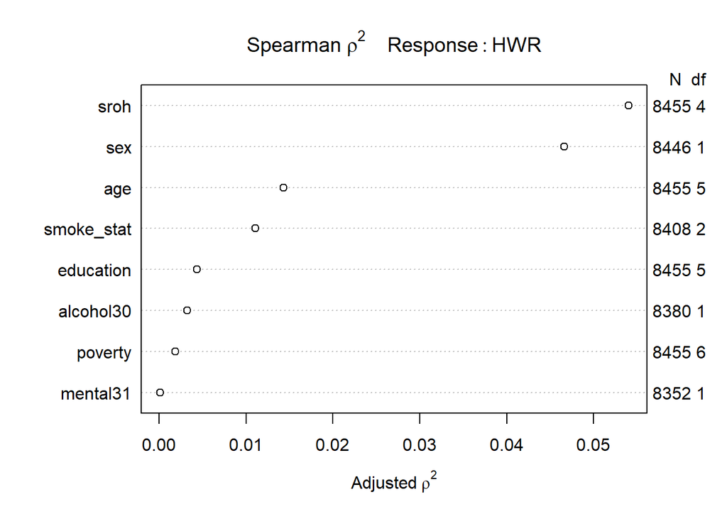

```r
plot(spear1)
```

### 2.6.3 What happens if we set p = 2 instead?

```r
spear2 <- spearman2(HWR ~ sex + sroh + alcohol30 + mental31 +
                   age + education + smoke_stat + poverty,
               data = omas17ne, p = 2)
spear2
```

```
Spearman rho^2    Response variable:HWR

            rho2      F df1  df2      P Adjusted rho2    n
sex        0.047 413.85   1 8444 0.0000         0.047 8446
sroh       0.054 121.62   4 8450 0.0000         0.054 8455
alcohol30  0.004  17.16   2 8377 0.0000         0.004 8380
mental31   0.002   7.36   2 8349 0.0006         0.002 8352
age        0.015  25.61   5 8449 0.0000         0.014 8455
education  0.005   8.41   5 8449 0.0000         0.004 8455
smoke_stat 0.011  48.20   2 8405 0.0000         0.011 8408
poverty    0.003   3.67   6 8448 0.0012         0.002 8455
```

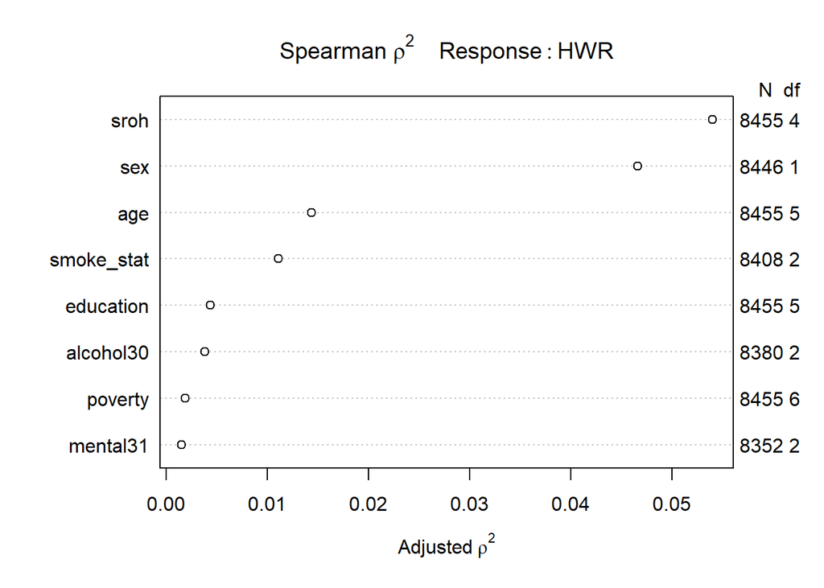

```r
plot(spear2)
```

## 2.7 Building an OLS model with non-linear terms

To come.

### 2.7.1 What exactly does `validate` do here?

To come.

### 2.7.2 What exactly does `calibrate` do here?

To come.

### 2.7.3 Using multiple imputation at various stages?

To come.

### 2.7.4 Using cross-validation to compare two models after multiple imputation?

To come.

# 3 Model Building for a Binary (categorical) Outcome

## 3.1 Again, working with a subsample: the Northeast Ohio Region

Let’s take a sample of the data, to describe the Northeast Ohio region.

```r
omas17ne2 <- omas17_cleaned %>%
    filter(region == "North_East") %>%
    filter(!is.na(avoid_care))

nrow(omas17ne2)
```

```
[1] 8238
```

## 3.2 Our outcome: Pr(Avoid or Delay Care in the past 12m)

```r
omas17ne2 %>% tabyl(avoid_care)
```

```
 avoid_care    n   percent
          0 6484 0.7870842
          1 1754 0.2129158
```

### 3.2.1 Variable Selection with Stepwise Logistic Regression

### 3.2.2 Spearman $\rho^2$ plot

### 3.2.3 Cross-Validation of Models with a Confusion Matrix

### 3.2.4 What exactly does `validate` do here?

To come.

### 3.2.5 What exactly does `calibrate` do here?

To come.

### 3.2.6 Using multiple imputation at various stages?

To come.